[figure not shown]

# Análisis de Brigadas en el estado de Aguascalientes: 2020-2021

M.C. Héctor René Becerril Cejudo

# Prefacio

En agosto de 2021 la Dirección Académica de la DGETAyCM solicitó información, por medio de los comisionados estatales, sobre diferentes aspectos de las Brigadas de Educación para el Desarrollo Rural (BEDR), utilizando un formato que logró capturar datos relevantes con el objetivo de construir una descripción más actualizada de estos centros de trabajo considerando su estructura y su operación. A través de este ejercicio piloto, se lograron observar diferentes situaciones, incluyendo algunos aspectos de mejora en el diseño del propio mecanismo de levantamiento de información, como puede ser el definir los tipos de datos a solicitar y los formatos de captura; se observó además la necesidad de diseñar un instructivo de llenado que incluya un glosario para el manejo de una terminología unificada.  
En el presente documento se muestran algunos de los aspectos observados en la estructura de la información obtenida y la forma en que se analizaron los datos en Aguascalientes. En una sección final se plantean algunas sugerencias en el diseño de los formularios para el levantamiento de información en el futuro. Espero que este esfuerzo de colaboración sea de gran utilidad para nuestras autoridades educativas en la tarea tan importante que realizan para el fortalecimiento de las BEDR. Finalmente, el aterrizaje de tan atinada iniciativa llevará a la mejora constante de éstos centros de trabajo que día a día realizan diferentes labores para coadyuvar en diferentes aspectos del desarrollo rural desde la educación, la asistencia técnica y la capacitación.

M.C.Héctor René Becerril Cejudo  
Comisionado estatal de la  
DGETAyCM en Aguascalientes.

# 1. Introducción

El compromiso de la Dirección General de Educación Tecnológica Agropecuaria y Ciencias del Mar en materia educativa es desarrollar enfoques innovadores en los sectores agrícola y pesquero para incrementar la productividad, conservar los recursos naturales y utilizar los insumos de manera sostenible y eficiente. Dentro de las atribuciones de la DGETAyCM figuran las siguientes por estar más relacionadas con las actividades actuales de seguimiento y de realizar nuevos planteamientos de mejora para las BEDR:

VII. Coordinar las actividades que permitan verificar que se cumplan las normas pedagógicas, contenidos, planes y programas de estudio, métodos, materiales didácticos e instrumentos para la evaluación del aprendizaje aprobados para la educación a que se refiere este artículo, en los centros de bachillerato tecnológico agropecuario, centros de estudio tecnológico forestal, unidades de capacitación para el desarrollo rural, brigadas rurales, centros de estudios tecnológicos del mar y centros de estudios tecnológicos en aguas continentales dependientes de la Secretaría;

VIII. Emitir las disposiciones técnicas y administrativas para la organización, operación, desarrollo y supervisión de la educación a que se refiere este artículo, así como una vez emitidas dichas disposiciones, coordinar su difusión y las actividades que permitan la verificación de su cumplimiento;

IX. Organizar y operar, en las instituciones educativas que impartan la educación prevista en este artículo y dependan de la Secretaría, la asesoría técnica como estrategia de apoyo que corresponda en términos de la Ley General del Sistema para la Carrera de las Maestras y los Maestros;

XI. Expedir certificados y, en su caso, títulos, así como otorgar constancias y diplomas a las personas que hayan concluido sus estudios conforme a los planes y programas autorizados a las instituciones educativas que impartan la educación a que se refiere este artículo y dependan de la Secretaría;

XXVIII. Coordinar la formación de técnicos en la educación a que se refiere este artículo, en coordinación con las dependencias y entidades competentes de la Administración Pública Federal, así como proporcionar la capacitación que le requieran los sectores agropecuario, forestal y pesquero;

XXIX. Proponer a la persona Titular de la Subsecretaría de Educación Media Superior la celebración de convenios de coordinación y concertación con los productores de bienes y servicios para desarrollar las prácticas profesionales y aquellas que sean necesarias para fortalecer el aprendizaje de las personas que reciben la educación a que se refiere este artículo;

[figure not shown]

En la imagen se observan algunos ejemplos de las ctividades de  
capacitación y de asistencia técnica brindadas por las brigadas de Aguascalientes.

# 2. Levantamiento de la información y análisis

La información fue capturada en nueve libros de **excel** en los que se integró la información de distintos temas referentes a las BEDR. Cosnideramos de gran importancia analizar la estructura de dicha información en los términos de los formatos de captura, esto nos será útil para poder avanzar hacia la construcción de un mecanismo lógico de captura de los datos que nos permita, en un futuro, no solamente analizar y administrar la información de manera ágil, sino principalmente, construir indicadores que sean de relevancia para el seguimiento y evaluación de actividades desde una perspectiva de mejora y fortalecimiento institucional.  
Se pudo observar que la información recibida no mantiene una consistencia que permita analizarla de forma directa. Se observaron amplias diferencias en la manera en que las Brigadas registraron la información. Si bien las hojas de excel donde se solicitó la captura indicaba en cada una de sus columnas el tipo de datos que se debía ingresar en cada celda, la captura no fue homogénea, lo que obligó a hacer una serie de correcciones previas para poder realizar este análisis.

### 2.1. Preparación de los datos

> Se seleccionó una parte de la información recibida y se almacenó en ocho hojas de un nuevo libro de **excel**. En cada una de las hojas se distribuyeron los diferentes temas y manteniendo campos relacionales que permitieran vincular la información. Para la manipulación y análisis de los datos se utilizó el lenguaje de programación **python** y los paquetes **pandas**, **numpy** y **matplotlib**.

Invocando los paquetes de **python** que se utilizan en el análisis.

```python
import pandas as pd
import numpy as np
import matplotlib.pyplot as plt
import scipy as sy
%matplotlib inline
```

La información extraída se guardó en un nuevo libro de **excel** que se llamó datos1 el cual contiene ocho hojas que se muestran a continuación:

```python
print(datos1.sheet_names)
```

```
['Act20-21', 'Rel_Per', 'ActAsig', 'ActAsigFuturo', 'ActApoyoPlant', 'FormDocent', 'Capa', 'Adeudos']
```

```python
dfPer = pd.read_excel(datos1, 'Rel_Per')
df2020=pd.read_excel(datos1, 'Act20-21')
dfCapa = pd.read_excel(datos1, 'Capa')
df2021 = pd.read_excel(datos1, 'ActAsigFuturo')
dfForDoc = pd.read_excel(datos1, 'FormDocent')
```

En los diferentes **DataFrames** fue necesario cambiar los nombres de algunas columnas para un manejo más simple y ágil.

```python
dfPer.rename(columns = {'Antiq_years':'Años en BEDR',
                        'Perfil Prefesiográfico':'Perfil',
                       'Nombre (S)':'Nombre',
                       'Apellido Paterno':'Paterno',
                       'Apellido Materno':'Materno'}, inplace = True)
```

### 2.2. Relación de personal

|  | CCT | Nombre | Paterno | Materno | RFC | Plaza | Perfil | CCT de adscripción | Años en la BEDR |
| --- | --- | --- | --- | --- | --- | --- | --- | --- | --- |
| 0 | 01HBR0001O | ROSA ISELA | AGUILAR | MARÍN | AUMR7307221E8 | 1802E436900.0180688 | LIC. EN EDUCACIÓN SECUNDARIA CON ESPECIALIDAD ... | 01HBR0001O | 25 |
| 1 | 01HBR0001O | JUAN ANTONIO | ARROYO | ALFARO | AOAJ821016KV1 | 1802E412900.0180106 | MÉDICO VETERINARIO ZOOTECNISTA | 01HBR0001O | 16 |
| 2 | 01HBR0001O | ALHELÍ | GOMEZ | QUIROGA | GOQA810425TX2 | 1802E432900.0180432 | ING. EN AGROECOLOGIA | 01HBR0001O | 4 |
| 3 | 01HBR0001O | ISMAEL | GONZÁLEZ | PARRA | GOPI7911302V3 | 1802E432700.0190997 | LIC. EN ADMINISTACIÓN FINANCIERA | 01HBR0001O | 3 |
| 4 | 01HBR0001O | ALDO MISAEL | GONZÁLEZ | SANTANA | GOSA7902084X2 | 9918YT0500300.0010001 | LIC. EN EDUCACIÓN SECUNDARIA CON ESPECIALIDAD ... | 01HBR0001O | 3 |
| 5 | 01HBR0001O | JENNIFER | HERNANDEZ | ALFARO | HEAJ921109AM4 | 1802YT1702100.0180083 | CONTADOR PÚBLICO | 01HBR0001O | 7 |
| 6 | 01HBR0001O | DAVID ROBERTO | MARTINEZ | DIAZ | MADD8405015U8 | 3502YA0400300.0100004 | LIC. EN INFORMATICA (PASANTE) | 01DTA0030C | 4 |
| 7 | 01HBR0001O | DHYONE SIDIM | MEDINA | GAYTAN | MEGD810726CB5 | 1802E432900.0191341 | LIC. EN EDUCACION SECUNDARIA ESP. QUIMICA Y MA... | 01HBR0001O | 15 |
| 8 | 01HBR0001O | JORGE | PALACIO | IBARROLA | PAIJ710218HUA | 1802E436700.0190427 | LIC. EN MARCADOTECNIA | 01HBR0001O | 26 |
| 9 | 01HBR0001O | AZUL CELESTE | SALDAÑA | ROJAS | SARA830907634 | 1801YA0102600.0000006 | TEC. CONTROL DE CALIDAD | 01HBR0001O | 17 |
| 10 | 01HBR0001O | MIGUEL ANGEL | ZEPEDA | MONTES | ZEMM8011164F0 | 1802E401719.0180353 | BACHILLERATO | 01HBR0001O | 18 |
| 11 | 01HBR0001O | JUAN IGNACIO | GONZALEZ | CHAVEZ | GOCJ560602R48 | 1802E436900.0000130 | ING. AGRÓNOMO ESPECIALISTA EN FRUTICULTURA | 01HBR0001O | 42 |
| 12 | O1HBR0108G | SALVADOR | AGUILERA | VELOZ | AUVS63078150 | 1802 E436900.0191304 | ING. AGRONOMO ZOOTECNISTA | O1HBR0108G | 11 |
| 13 | O1HBR0108G | AMADOR | CUEVA | SAÚL | AACS5504143U7 | 1802 E436900.0000129 | ING. AGRONOMO | O1HBR0108G | 24 |
| 14 | O1HBR0108G | OLGA | ALCALÁ | LÓPEZ | AALO5707156V9 | 113011802 E436900.0190947 | LIC. EN SOCIOLOGÍA | O1HBR0108G | 24 |
| 15 | O1HBR0108G | MARCO ANTONIO | BERNAL | RUVALCABA | BERM580729E43 | 1802 E436900.0180876 | MED. VETERINARIO ZOOTECNISTA | O1HBR0108G | 21 |
| 16 | O1HBR0108G | MA. NATIVIDAD | DIAZ DE LEON | GONZALEZ | DIGN6502057Z2 | 1802 E436900.0180918 | ING. AGRONOMO EN DESARROLLO RURAL | O1HBR0108G | 4 |
| 17 | O1HBR0108G | LAURA ELENA | DITTRICH | REYES | DIRL750430CK1 | 1802 E416700.0180271 | LIC. EN EDUC. SEC.EN FORMACION DE CIVICA Y ETICA | O1HBR0108G | 4 |
| 18 | O1HBR0108G | EMMANUEL | GARCÍA | LEÓN | GALE910829R10 | 113011802YT2600500.0180036 | ING. EN ELECTRONICA | O1HBR0108G | 5 |
| 19 | O1HBR0108G | RITA | GONZALEZ | JIMENEZ | GOJR631013CX7 | 1802 E436900.0191357 | ING. AGRONOMO | O1HBR0108G | 2 |
| 20 | O1HBR0108G | ROBERTO | HERRERA | SALDAÑA | HESR490522R47 | 1802 E436900.0000131 | ING. AGRONOMO, MAESTRÍA EN CIENCIAS EN ECONOMI... | O1HBR0108G | 24 |
| 21 | O1HBR0108G | ALMA DELIA | LEÓN | MANCERA | LEMA730923J84 | 113011802YA0100100.0180133 | BACHILLERATO TECNOLOGICO | O1HBR0108G | 2 |
| 22 | O1HBR0108G | VIRGINIA | MONTOYA | ESPARZA | MOEV6208297GA | 113011802 E436900.0191335 | ING. AGRONOMO | O1HBR0108G | 15 |
| 23 | O1HBR0108G | NOELIA | RAMIREZ | NAVARRETE | RANN751110H64 | 1802YA0100100.0180095 | LIC. EN EDUC. SEC.EN FORMACION DE CIVICA Y ETI... | O1HBR0108G | 18 |
| 24 | O1HBR0108G | ZULAID | ROBLEDO | LOZANO | ROLZ830710SG1 | 1802 E426700.0180577 | LIC. EN DERECHO, MAESTRÍA EN EDUCACION | O1HBR0108G | 3 |
| 25 | O1HBR0108G | IVAN ULISES | ROMO | DELGADO | RODI850921TX6 | 1802 E432500.0190023 | LIC. EN URBANISMO | O1HBR0108G | 8 |
| 26 | O1HBR0108G | JORGE OMAR | ROMO | GUITIERREZ | ROGJ8308099E0 | 110071802A0803400.0180034 | LIC. EN INTERVENCIÓN EDUCATIVA | O1HBR0108G | 11 |

Debido a la gran amplitud de carreras que definen el perfil profesional del personal de Brigadas, para el diseño de posteriores formularios de captura se sugiere agregar un campo que se llame **'Perfil por area disciplinar'** que permita agregar la información y compactarla en áreas como: ingeniería, ciencias de la tierra, humanidades, pedagogía, etc.

### 2.3. Perfiles profesionales

La diversidad de perfiles puede llegar a ser una gran ventaja de la que tendrá que sacarse provecho en la actualidad en un mundo diverso y cambiante.

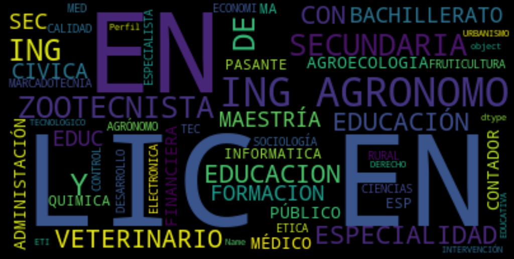

### 2.4. Antiguedad en BEDR

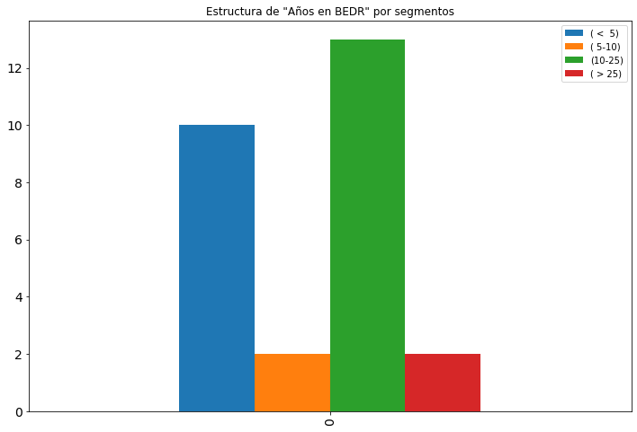

### 2.5. Formación docente

> La **Brigada No.16** reporta nueve cursos de formación docente debidamente concluidos, mientras que la **Brigada No.108** reporta un total de siete cursos debidamente concluídos. El curso con mayor participación de brigadistas fue *'El ciudadano que queremos formar a partir de la NEM'*. los cursos con menor participación fueron aquellos relacionados con las habilidades digitales y prácticas directivas.

|  | RFC | CCT | Cursos concluídos | Necesidades de capacitación | PRUEBA |
| --- | --- | --- | --- | --- | --- |
| 0 | GOQA810425TX2 | 01HBR0001O | “Componentes de la tutoria docente en la EMS" | Elaboración de Plan de Negocios. | Comercialización\nBiofertilizantes |
| 1 | NaN | 01HBR0001O | "Apoyo psicosocial y docencia en preparación p... | Innovación agroalimentaria | Formulación de proyectos\nConservas |
| 2 | NaN | 01HBR0001O | “Componentes de la tutoria docente en la EMS" | Postres Saludables | Comercialización\nManejo Integrado de Plagas\n... |
| 3 | PAIJ710218HUA | 01HBR0001O | "Apoyo psicosocial y docencia en preparación p... | Proceso de comercialización de producto termin... | Análisis de suelos\nComercialización\nNutrició... |
| 4 | PAIJ710218HUA | 01HBR0001O | “Componentes de la tutoria docente en la EMS" | Huertos Verticales | Formulación de proyectos\nConservas\nComercial... |
| 5 | PAIJ710218HUA | 01HBR0001O | "El ciudadano que queremos formar a partir de ... | NaN | Manejo Integrado de Plagas |
| 6 | AUMR7307221E8 | 01HBR0001O | "Apoyo psicosocial y docencia en preparación p... | NaN | Comercialización\nFormulación de proyectos |
| 7 | AUMR7307221E8 | 01HBR0001O | "El ciudadano que queremos formar a partir de ... | NaN | Formulación de proyectos\nComercialización\nTIC |
| 8 | MEGD810726CB5 | 01HBR0001O | "El ciudadano que queremos formar a partir de ... | NaN | Conservas\nEcotecnias\nFormulación de proyectos |

|  | RFC | CCT | Cursos concluídos | Necesidades de capacitación | PRUEBA |
| --- | --- | --- | --- | --- | --- |
| 9 | AUVS63078150 | O1HBR0108G | El ciudadano que queremos formar a partir de l... | Uso y manejo de las tecnologías de la info... | Comercialización\nBiofertilizantes\nConservas |
| 10 | AUVS63078150 | O1HBR0108G | El ciudadano que queremos formar a partir de l... | La nube y sus aplicaciones | Comercialización |
| 11 | GOJR631013CX7 | O1HBR0108G | El ciudadano que queremos formar a partir de l... | NaN | Repostería\nComercialización\nConservas |
| 12 | DIGN6502057Z2 | O1HBR0108G | El ciudadano que queremos formar a partir de l... | NaN | Formulación de proyectos\nTIC |
| 13 | DIRL750430CK1 | O1HBR0108G | El ciudadano que queremos formar a partir de l... | NaN | Biofertilizantes\nAnálisis de suelos |
| 14 | DIRL750430CK1 | O1HBR0108G | Inducción a la Práctica Directiva en el NMS. | NaN | Conservas |
| 15 | DIRL750430CK1 | O1HBR0108G | Habilidades digitales para la formación en línea. | NaN | Formulación de proyectos\nTIC\nComercialización |

| CCT | Cursos concluídos | No. de personas que lo concluyeron |  |
| --- | --- | --- | --- |
| 01HBR0001O | "Apoyo psicosocial y docencia en preparación para el regreso a clases" | 3 |  |
|  | "El ciudadano que queremos formar a partir de la NEM " | 3 |  |
|  | “Componentes de la tutoria docente en la EMS" | 3 |  |
| O1HBR0108G | El ciudadano que queremos formar a partir de la nueva Escuela Mexicana en la EMS. | 4 |  |
|  | Habilidades digitales para la formación en línea. | 1 |  |
|  | Inducción a la Práctica Directiva en el NMS. | 1 |  |

### 2.6. Necesidades de capacitación

> En cuanto a las necesidades de capacitación resalta la poca demanda de cursos reportados. En la **Brigada 16** se registraron cinco personas que manifestaron necesidad de capacitación en los siguientes temas: *'elaboración de plan de negocios, huertos verticales, innovación agroalimentaria, postres saludables y comercialización'*. La **Brigada 108** por su parte rgistró necesidades de capacitación en dos temas: *'manejo de tecnologías de la información, la nube y sus aplicaciones'*.

| CCT | Necesidades de capacitación | No. de interesados |  |
| --- | --- | --- | --- |
| 01HBR0001O | Elaboración de Plan de Negocios. | 1 |  |
|  | Huertos Verticales | 1 |  |
|  | Innovación agroalimentaria | 1 |  |
|  | Postres Saludables | 1 |  |
|  | Proceso de comercialización de producto terminado. | 1 |  |
| O1HBR0108G | 1.- Uso y manejo de las tecnologías de la información y comunicación | 1 |  |
|  | 2.- La nube y sus aplicaciones | 1 |  |

### 2.7. Servicios y acciones durante el ciclo 2020-2021

|  | CCT | Servicios ofrecidos por la BEDR | Acciones  | Retos | Estrategias y logros |
| --- | --- | --- | --- | --- | --- |
| 0 | 01HBR0001O | Elaboración y difusión de tutoriales | Se realizaron video tutoriales de diversos con... | Conexión a internet, Equipo de grabación , cap... | Estrategia: Derivado de la contingencia se red... |
| 1 | 01HBR0001O | Cursos de Capacitación en Línea | Se llevaron a cabo 6 cursos de capacitación en... | Debido a que con video tutoriales no se podía ... | La estrategia a seguir se centro en la imparti... |
| 2 | 01HBR0001O | Asesoría y Asistencia Técnica | Se realizaron un total de 39 asesorías y 13 as... | En el caso de la Asistencia y asesoría técnica... | La estrategia : Diseñar un plan hibrido para r... |
| 3 | 01HBR0001O | Campañas | Concientización del uso de métodos anticoncept... | NaN | Se realizo una transmisión en vivo , donde una... |
| 4 | 01HBR0001O | Campañas | Ciencia y la Tecnología | NaN | Se realiza una presentación en power point alu... |
| 5 | 01HBR0001O | Campañas | Campaña de vacunación y desparasitación | Por cuestiones de pandemia el numero de person... | Esta actividad se realiza en conjunto con el c... |
| 6 | 01HBR0001O | Campañas | Campaña de lentes | Se reprogramo esta actividad debido a la conti... | Se invita a los habitantes de la comunidad Sec... |
| 7 | 01HBR0001O | Gestorías | Se solicitaron de 20 estuches de geometría, mi... | NaN | Durante las visitas a las comunidades se distr... |
| 8 | 01HBR0001O | Gestorías | Se emitió solicitud a la fundación FAVENT para... | NaN | Se solicita el apoyo para que por medio de la ... |
| 9 | 01HBR0001O | Gestorías | Se solicito la impartición de un curso de merm... | Se genero la petición por parte de la autorida... | Se trabajo de manera conjunta con el IMEPP par... |
| 10 | 01HBR0001O | Gestorías | Se solicita 171 cajas de diverso medicamento a... | NaN | Este apoyo se disperso directamente a la Deleg... |
| 11 | 01HBR0001O | Gestorías | Se gestiona 10 pruebas de embarazo | NaN | Se hace entrega de las pruebas de embarazo en ... |
| 12 | 01HBR0001O | Actualización Docente | Se asistió a diverso talleres, videoconferenci... | Falla en las conexiones a internet y duplicida... | Se estableció asistir en su mayoría a todas la... |

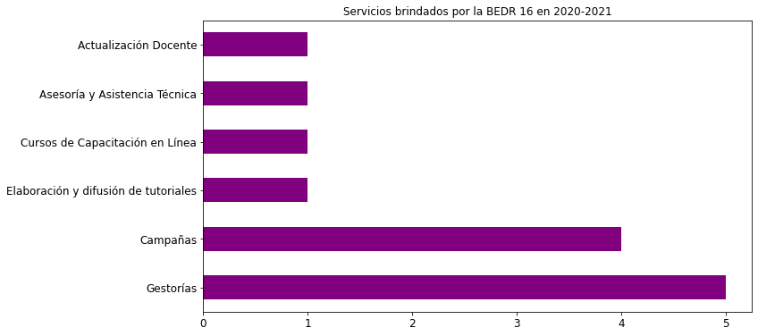

|  | CCT | Servicios ofrecidos por la BEDR | Acciones  | Retos | Estrategias y logros |
| --- | --- | --- | --- | --- | --- |
| 13 | O1HBR0108G | Elaboración y difusión de Video-Tutoriales | Se realizó la Impartición de 8 cursos a través... | La actualización de todo el personal de la Bri... | En total se realizaron 72 Video-Tutoriales que... |
| 14 | O1HBR0108G | Impartición de Cursos a distancia | Se impartieron 6 cursos en línea | La actualización de todo el personal de la Bri... | Estos cursos se impartieron través de transmis... |
| 15 | O1HBR0108G | Impartición de Cursos Presenciales | Se impartieron 5 cursos presenciales | La actualización de todo el personal de la Bri... | Conforme lo permitió el semáforo epidemiológic... |
| 16 | O1HBR0108G | Apoyo en módulos y submódulos | Se apoyo en la impartición del módulo "ELABORA... | NaN | Se apoyo a un grupo de 27 estudiantes del CBTA... |
| 17 | O1HBR0108G | Asesorías Técnicas | Se apoyó a los productores a resolver problema... | NaN | Se beneficio a 193 personas a través de 182 as... |
| 18 | O1HBR0108G | Asistencias Técnicas | Se apoyó a los productores a resolver problema... | NaN | Se beneficio a 39 personas a través de 27 asis... |
| 19 | O1HBR0108G | Difusión de Campañas Ambientales | A través de sesiones transmitidas en vivo se r... | NaN | Etas sesiones fueron transmitidas a través de ... |
| 20 | O1HBR0108G | Gestorías | Durante este ciclo se tramitaron ante instituc... | NaN | Durante este ciclo escolar se logro beneficiar... |
| 21 | O1HBR0108G | Difusión de Actividades | Para tener un mayor alcance y llegar a más per... | NaN | Para lograr esto los docentes crearon grupos d... |
| 22 | O1HBR0108G | Dispensario Médico | Derivado de diversas gestiones se implementó e... | NaN | Este programa fue difundido por medio de los p... |
| 23 | O1HBR0108G | Acuerdos de colaboración | Vincular acciones para ampliar los servicios e... | Concretar los aspectos señalados en los acuerd... | Se concretaron importantes acuerdos: Con la Br... |
| 24 | O1HBR0108G | Apoyo a planteles y colaboración con instituci... | Contribuir al trabajo en conjunto y apoyar en ... | Estar en condiciones necesarias para poder apoyar | Se apoyó a Brigada No. 08 de Ojocaliente Zacat... |
| 25 | O1HBR0108G | Plan de trabajo conjunto con los CBTAS en el E... | Establecer acciones en beneficio de la educaci... | Establecer estrategias adecuadas para concreta... | C.B.T.A. No. 30: Implementación del curso virt... |
| 26 | O1HBR0108G | Actualización Docente | Se capacito de acuerdo a las necesidades para ... | Que el docente se capacite con base a las nece... | Se dio la apertura para que cada docente se ca... |
| 27 | O1HBR0108G | Conferencias virtuales | Realización de conferencias para los docentes ... | Llevar información pertinente a las personas q... | Se realizaron 4 conferencias y un foro por med... |

Existe una gran variedad de servicios y actividades que realizan las Brigadas. Sin embargo, es necesario redefinir el marco de acción y adecuarlo a un enfoque institucional y sectorial actualizado.

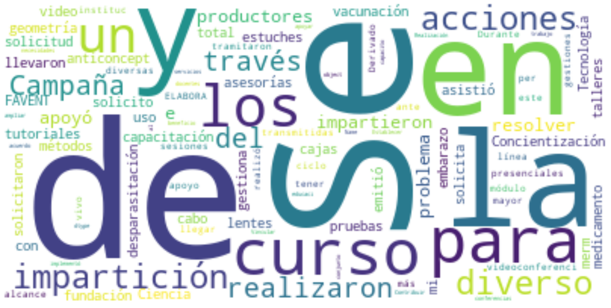

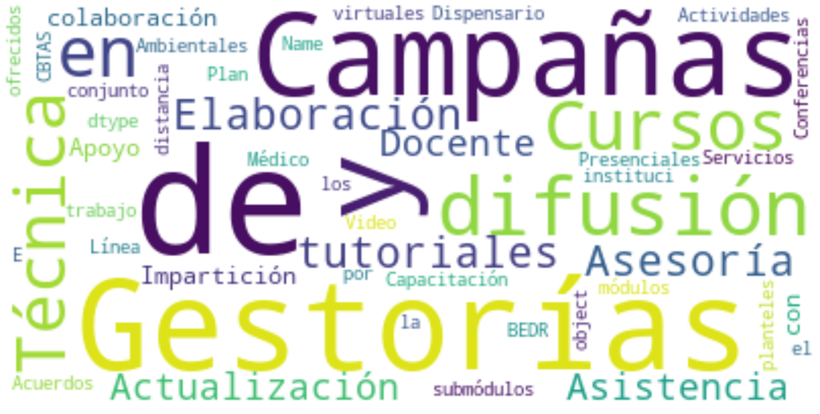

### 2.8. Actividades para el ciclo 2021-2022

> Para el período 2021-2022 agost-enero, las dos Brigadas consideran un abanico de 36 distintas actividades que se distribuyeron entre el personal. La **Brigada 16** reportó un total de 14 distintas actividades que fueron asignadas a 11 integrantes de la Brigada. Por su parte, la **Brigada 108** reportó un total de 22 distintas actividades asignadas a ocho diferentes integrantes.

|  | CCT | RFC | Actividades del semestre septiembre 2021- enero 2022 |
| --- | --- | --- | --- |
| 0 | 01HBR0001O | AUMR7307221E8 | Reuniones de academia en línea y/o presencial |
| 1 | 01HBR0001O | AUMR7307221E8 | Sesiones de mejora continua en el docente, (as... |
| 2 | 01HBR0001O | AUMR7307221E8 | Elaboración, edición y difusión de cursos de c... |
| 3 | 01HBR0001O | AUMR7307221E8 | Gestión interinstitucional, gestiones de accio... |
| 4 | 01HBR0001O | AUMR7307221E8 | Proporcionar servicios de asesoría, asistencia... |
| ... | ... | ... | ... |
| 115 | O1HBR0108G | RODI850921TX6 | PROPORCIONAR SERVICIOS DE ASISTENCIA TÉCNICA A... |
| 116 | O1HBR0108G | RODI850921TX6 | GESTORÍA DE APOYO ANTE INSTITUCIONES Y ORGANIS... |
| 117 | O1HBR0108G | RODI850921TX6 | DIFUSIÓN DE ACTIVIDADES DE LA BRIGADA, CAPACI... |
| 118 | O1HBR0108G | RODI850921TX6 | ACTUALIZACIÓN DOCENTE |
| 119 | O1HBR0108G | RODI850921TX6 | SEGUIMIENTO DE ACTIVIDADES DEL PROYECTO DE PRE... |

120 rows × 3 columns

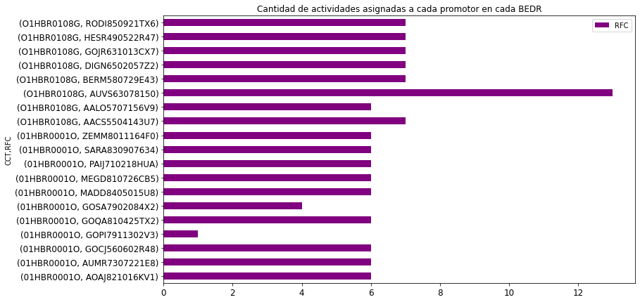

# 3. Comentarios

Las dos Brigadas en la entidad tienen características distintas y muy particulares, una de las grandes diferencias es la proporción de **perfiles con orientación agropecuaria** con que cuenta cada una de ellas, aspecto en el que la BEDR 108 se ve más fortalecida. Sien embargo, ambas Brigadas cuentan con una notable **diversidad de perfiles** profesionales entre su personal, lo que puede aprovecharse para enriquecer aún más la oferta de capacitaciones y actividades. Por otro lado, en ambas brigadas existe una proporción equilibrada con respecto a la cantidad de personal de reciente ingreso y personal con más de 15 años de experiencia como brigadista; esto es importante para el fortalecimiento de las Brigadas debido a que de esta manera se establecen mecanismos de formación y desarrollo de capacidades entre los docentes mediante el intercambio de experiencias.  
Durante este ejercicio se identificaron algunos aspectos de mejora propios del procedimiento de levantamiento de la información. Una de las principales recomendaciones es facilitar un **manual** para el llenado, donde además se integre un **glosario** de términos y unidades de medida. Debido a esto, es importante que el diseño del formato de encuesta se realice habiendo identificado **previamente** los **indicadores** que se necesitan observar, así como sus **unidades de medida** y su **periodicidad**, para que en función de dichos indicadores se determine el tipo de datos a censar; una vez definidas las variables de respuesta y los mecanismos de levantamiento, entonces será posible describir y monitorear los diferentes aspectos referentes a la operación de las BEDR. Las distintas variables ordinales, nominales o de escala que se definan, condicionarán el diseño de un mecanismo de flujo adecuado para una buena administración de la información y un ágil y constante análisis de la misma que permita la **oportuna toma de decisiones**.

M.C.Héctor René Becerril Cejudo

[figure not shown]